# Student Possibility Series

Email 1 · Mon Nov 9

Your first client might be a taco truck

One picture. One business. That's the whole first move.

I want you to try something tonight.

Pick one local spot you actually go to. The taco truck.  
Your barber. The nail shop next to the gas station.

Now pull up their Instagram.

Last post: two months ago. A blurry photo of the menu. 😬

That's not a sad story.

That's an OPENING.

Because here's what you can do from your phone, right now:

Open ChatGPT or Higgsfield. Type what you want. "Bold promo image for a taco truck. $2 Tuesdays. Neon sign vibe."

Hit enter.

Under a minute later you're holding this:

[figure not shown]

*That's real. That's what came back from that exact sentence.*

Looks like a design agency made it. 🤯

You didn't go to art school. You didn't learn Photoshop.  
You just made a business look better than it did this morning.

Now send it to them. "Hey, I made this for you. It's free.  
Want one every week?"

That's it. **That's the whole first move.**

My first client was a pizza shop on Melrose. It started as a conversation over dinner. No pitch deck. No portfolio. 🍕

And businesses pay for this. Our agency's creative packs start at $750. That's ONE business, buying ONE time.

You can make it from your couch. From the bus. From a different country. The picture doesn't know where you were sitting.

I'm telling you now because the door is WIDE open. The tools just got this good, and the taco truck hasn't caught up yet.

I believe you can do this. Not "maybe." I believe it.

The book shows you how to pick ONE skill and get paid for it inside 90 days.

👉 [Get From Xbox to Executive](https://joineat4life.com/xboxtoexec?utm_source=email&utm_medium=student&utm_campaign=S1-2026-11-09)

Holla Back – Get ya Dolla Back. ✊🏾  
Sebastian  
Eat 4 Life

P.S. I gotta question: what's the first spot you'd make one for?

Eat 4 Life Marketing · 215 E Regent St, Inglewood, CA 90301  
Unsubscribe

Email 2 · Fri Nov 20

Type one paragraph. Get a website.

No code. No templates. Just tell it what the business does.

Quick test.

Think of a business you've tried to look up and couldn't find. Or found a website that looked like 2009 and broke on your phone.

You know the one.

That business is losing customers every single day it stays that way. And you can fix it tonight. 👀

Here's how easy it got:

Open Claude. Describe the business like you're telling a friend.

"One-page site for Maria's Braids in Inglewood. Prices, a booking button, her hours, gold and black."

It builds the page. Right there. You can click around in it.

[figure not shown]

*What Claude built from that one sentence. Example only, not a real business.*

Don't like the colors? Say "make it purple." Want photos?  
Say "add a gallery." You're not coding. You're *talking.*

Getting it onto the business's own web address takes a few more steps. But the hard part, the design and the words, is done before your food gets cold.

**If you can describe it, you can build it.**

And businesses pay real money for pages that bring in customers. Our agency's interactive pages start at $500 a month. For ONE business.

One client. Every month.

That's not a side hustle. That's rent.

And you can build it from the library, your cousin's couch, or a beach. The website doesn't care where you were. ✈️

Right now most people don't know this is possible. That gap is your window, and windows close.

I believe you're the one who's gonna walk through it.

The book shows you how to pick ONE skill and get paid for it inside 90 days.

Holla Back – Get ya Dolla Back. ✊🏾  
Sebastian  
Eat 4 Life

P.S. What's the worst business website you've seen this month? Hit reply and send it to me. I wanna see it. 😂

Eat 4 Life Marketing · 215 E Regent St, Inglewood, CA 90301  
Unsubscribe

Email 3 · Mon Dec 7

Your gaming hours were the training

Now build the game. And put a business inside it.

You know what keeps somebody hitting "play again" at 2am better than any marketing professor alive.

You've been studying it for years. The reward. The streak.  
The "one more round."

People told you that was wasting time. 🎮

Here's what's crazy. You can build a game now just by describing it.

Open Claude. Say "make me a spin-the-wheel game for a coffee shop. Customers spin once a day and win a free cookie or 10% off."

It builds it. Playable. Right there in the chat.

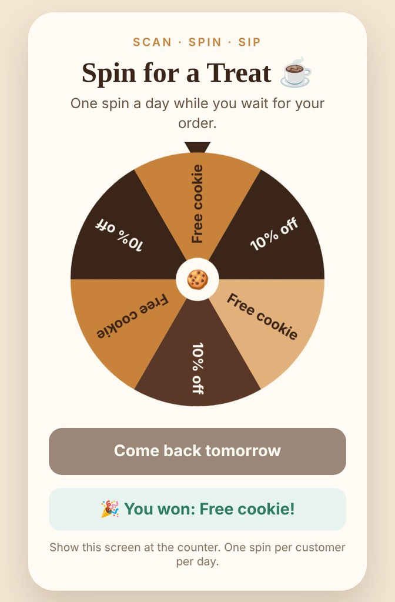

*That's the real game Claude built from that sentence. It spins, and it only lets you play once a day.*

And Astra, OpenAI's newest model, came out in September.  
People are already posting whole games they built with it.

Now picture it.

A QR code on the counter. You scan it while you wait for your latte. Thirty seconds of a game. You win a cookie.

You're coming back tomorrow to spin again. Aren't you? 😏

THAT is marketing. And you already understand it better than the coffee shop owner does.

Businesses pay for this. Our agency's interactive quiz pages start at $500 a month. A quiz is just a game with a coupon at the end.

ONE coffee shop. Every month.

Remember when people said gaming would never pay? People laughed.

Then it stopped being funny.

**Build the game. Put a business inside it.**

You can do it from the same chair you've been gaming in.  
I'm not even playing. Same chair.

The door is open RIGHT now. The tools are this new, and the coffee shop on your corner has never heard of them.

I believe you can do this. I believe it because I was you.

The book shows you how to pick ONE skill and get paid for it inside 90 days.

👉 [Get From Xbox to Executive](https://joineat4life.com/xboxtoexec?utm_source=email&utm_medium=student&utm_campaign=S1-2026-12-07)

Holla Back – Get ya Dolla Back. ✊🏾  
Sebastian  
Eat 4 Life

P.S. Everybody who said you "wasted" your summer gaming is about to see the best coupon in town. Made by you. 💪🏾

Eat 4 Life Marketing · 215 E Regent St, Inglewood, CA 90301  
Unsubscribe

Email 4 · Mon Dec 14

No camera. No actors. Still a video ad.

Our mascot was made with AI. So can their next ad.

Meet Malik.

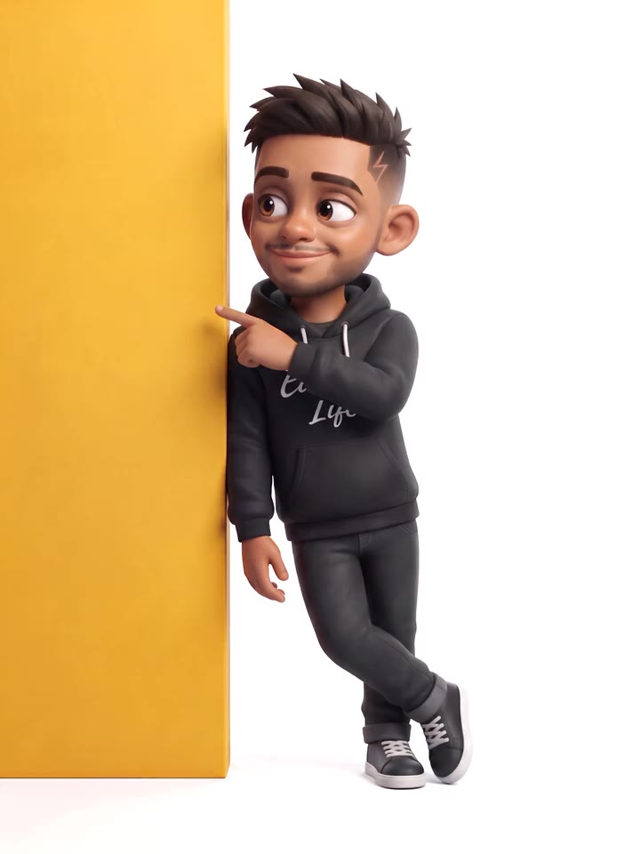

He's the mascot for my agency. He's got a personality.  
He answers questions. People like him.

Nobody sketched him. No animation studio. No art team. 👀

We made him with the same AI tools we use for client content.

Here's why that matters to you.

Every small business needs video now. The hot sauce guy at the farmers market. The candle shop. The food truck with a line around the block.

Most of them have a great product and zero video.

Here's what you do:

Take one photo of the product. Drop it into Higgsfield.  
Pick a style.

A few minutes later you've got a video ad. Camera moves.  
Lighting. The whole thing.

Need a script? Ask Claude. "Write a 15-second ad for small- batch hot sauce. Funny. Ends with a farmers market date."

**One photo is a video now.**

No film crew. No location. No 5am call time. 🎬

And businesses pay for this every month. Our agency's video service, a steady stream of short-form ads and content for a business, starts at $497 a month.

ONE business. Every month.

I used to think you needed a studio to make anything that looked professional. Now you need a phone and a good idea.

You can make these from your bedroom. Your car on lunch break. A hostel in another country. The video doesn't know.  
✈️

Don't wait until everybody knows this. Right now, the person who knows is you.

I believe in you on this one. Seriously.

The book shows you how to pick ONE skill and get paid for it inside 90 days.

👉 [Get From Xbox to Executive](https://joineat4life.com/xboxtoexec?utm_source=email&utm_medium=student&utm_campaign=S1-2026-12-14)

Holla Back – Get ya Dolla Back. ✊🏾  
Sebastian  
Eat 4 Life

P.S. Malik is on our agency's website if you want to meet him. He'll answer your questions. He'll never ask for a raise. 😂

Eat 4 Life Marketing · 215 E Regent St, Inglewood, CA 90301  
Unsubscribe

Email 5 · Mon Dec 21

Not into businesses? Cool. Help an artist.

Rappers, streamers, painters. They need this more than the pizza shop does.

Real talk.

Maybe walking into a barbershop with a laptop just isn't you.

That's fine. There's another door.

Creatives.

The rapper with a song but no cover art. The streamer with 800 followers and no clips. The painter whose work is incredible and whose Instagram is not. 🎨

Every one of them hits the same wall. They finished the art. Now they need everything AROUND the art.

Cover art. A ten-second promo clip. A page to send people to. Somebody to say "here's the plan."

That's you now.

Cover art concept? ChatGPT or Higgsfield, one sentence.  
Like this one: "Single cover art for an up-and-coming rapper's song called NIGHT SHIFT. Moody city lights at 3am, bold title type."

[figure not shown]

*That's exactly what came back. First try.*

Promo clip? Higgsfield turns the cover into motion.  
The link page? Claude builds it while you describe it.

That's a whole rollout kit. Made from one chair. 🔥

I'm a published musician. I know what it feels like when the thing you made is ready and nobody's seen it yet.

Let me be straight with you about money here. Artists usually have smaller budgets than a dental office. Your first one might be a trade, a shoutout, or a piece for your portfolio.

Your tenth one won't be.

And you'll be spending your days around the thing you love instead of the thing that pays the bills. That's the rat race, broken, one artist at a time.

**Help one creative look like they already made it.**

The tools are brand new. The artists you know are still doing it the hard way. Go be the shortcut.

I believe in you. And I believe in the people you're about to help.

The book shows you how to pick ONE skill and get paid for it inside 90 days.

👉 [Get From Xbox to Executive](https://joineat4life.com/xboxtoexec?utm_source=email&utm_medium=student&utm_campaign=S1-2026-12-21)

Holla Back – Get ya Dolla Back. ✊🏾  
Sebastian  
Eat 4 Life

P.S. I gotta question: who's the first artist you'd want to help? Reply with their name. I read these. ✍🏾

Eat 4 Life Marketing · 215 E Regent St, Inglewood, CA 90301  
Unsubscribe